# Tugas Pertemuan 4

Proses MA(2), AR(2), dan ARMA(2,2)

reva yulita

16 September 2026

# 1 Deskripsi Singkat Tugas

Tugas ini bertujuan mensimulasikan tiga proses time series stasioner melalui program **R**, yaitu **MA(2)**, **AR(2)**, dan **ARMA(2,2)**, masing-masing sebanyak **300 data**. Setiap proses dibangkitkan dengan **dua cara** — secara **manual** (mengikuti rumus model langsung) dan menggunakan fungsi bawaan **`arima.sim`** — sebagai bentuk validasi silang antara pemahaman rumus dan hasil fungsi R. Untuk setiap proses, dilakukan identifikasi kestasioneran melalui plot time series, ACF, PACF, dan EACF, pembuatan scatterplot antar-lag, serta perbandingan autokorelasi empiris (dari data) dengan autokorelasi teoritis (dari rumus populasi).

# 2 Persiapan

```r
library(TSA)
set.seed(123)
n <- 300
```

# 3 Proses MA(2)

Model yang disimulasikan: $Y_t = e_t + \theta_1 e_{t-1} + \theta_2 e_{t-2}$, dengan $\theta_1 = 0.4$ dan $\theta_2 = 0.6$. Secara teori, proses MA **selalu stasioner** untuk parameter berapa pun, karena $Y_t$ hanya merupakan kombinasi linear dari sejumlah terbatas error, tanpa komponen rekursif terhadap $Y_{t-1}$.

## 3.1 Membangkitkan Data

```r
theta1 <- 0.4
theta2 <- 0.6

# Cara 1: manual, mengikuti rumus MA(2) langsung
e <- rnorm(n + 2, mean = 0, sd = 1)
Y_MA2_manual <- numeric(n)
for (t in 1:n) {
  Y_MA2_manual[t] <- e[t + 2] + theta1 * e[t + 1] + theta2 * e[t]
}
Y_MA2_manual <- ts(Y_MA2_manual)

# Cara 2: menggunakan fungsi bawaan arima.sim
Y_MA2_sim <- arima.sim(model = list(ma = c(theta1, theta2)), n = n)
```

## 3.2 Plot Time Series

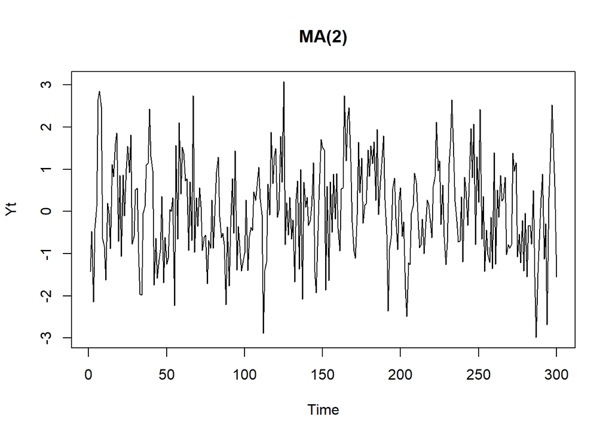

```r
plot.ts(Y_MA2_sim, main = "MA(2)", ylab = "Yt")
```

**Interpretasi:** deretnya berfluktuasi di sekitar rata-rata yang konstan (mendekati nol), dan lebar sebarannya juga relatif sama dari awal sampai akhir, tidak ada tren naik atau turun.

## 3.3 Plot ACF, PACF, dan EACF

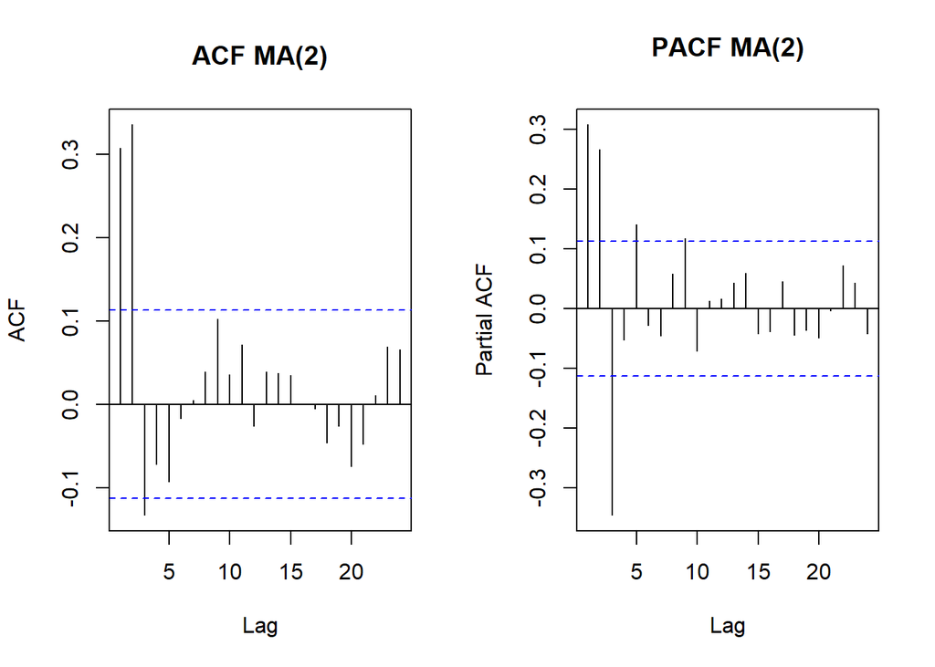

```r
par(mfrow = c(1, 2))
acf(Y_MA2_sim, main = "ACF MA(2)")
pacf(Y_MA2_sim, main = "PACF MA(2)")
```

```r
eacf(Y_MA2_sim)
```

```
## AR/MA
##   0 1 2 3 4 5 6 7 8 9 10 11 12 13
## 0 x x x o o o o o o o o  o  o  o
## 1 x x x o o o o o o o o  o  o  o
## 2 x x x x o o o o o o o  o  o  o
## 3 x x x o x o o o o o o  o  o  x
## 4 x x o o o x o o o o o  o  o  o
## 5 x x o o o x x o o o o  o  o  o
## 6 x x o o o x o x o o o  o  o  o
## 7 x x o x x o x x x o o  o  o  o
```

## 3.4 Scatterplot Antar-Lag

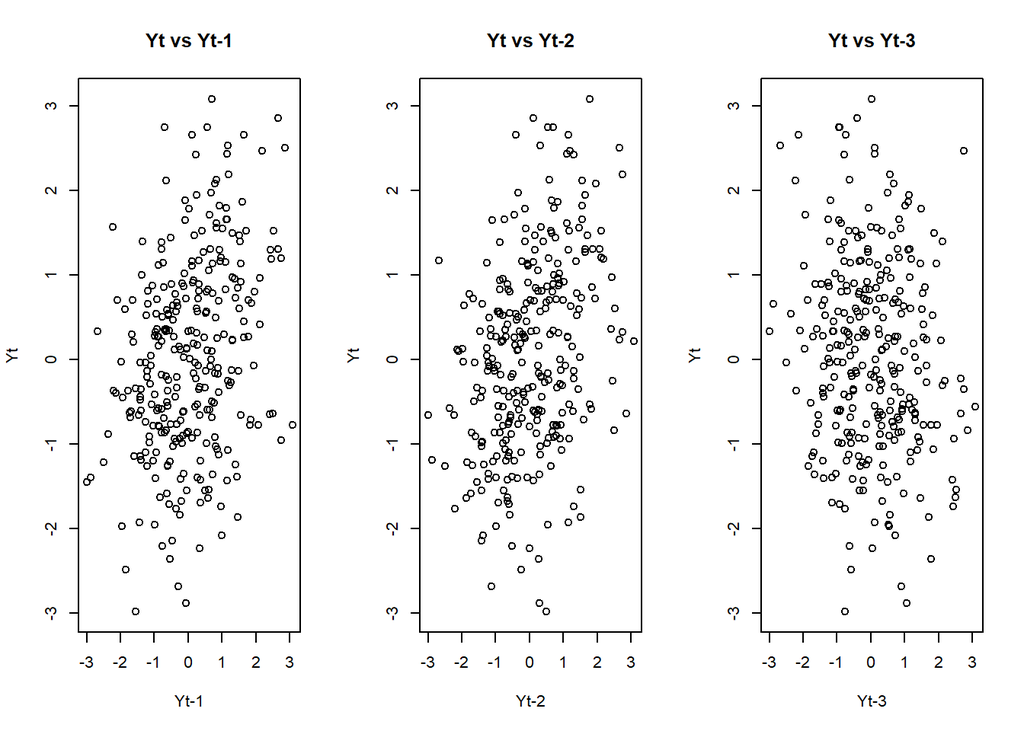

```r
par(mfrow = c(1, 3))
plot(Y_MA2_sim[-n], Y_MA2_sim[-1], xlab = "Yt-1", ylab = "Yt",
     main = "Yt vs Yt-1")
plot(Y_MA2_sim[1:(n-2)], Y_MA2_sim[3:n], xlab = "Yt-2", ylab = "Yt",
     main = "Yt vs Yt-2")
plot(Y_MA2_sim[1:(n-3)], Y_MA2_sim[4:n], xlab = "Yt-3", ylab = "Yt",
     main = "Yt vs Yt-3")
```

**Interpretasi:** scatterplot $Y_t$ vs $Y_{t-1}$ dan $Y_t$ vs $Y_{t-2}$ menunjukkan sedikit kecenderungan pola (titik tidak sepenuhnya acak), mengindikasikan adanya korelasi pada kedua lag tersebut. Sebaliknya, scatterplot $Y_t$ vs $Y_{t-3}$ tampak menyebar tanpa pola yang jelas (mendekati acak), konsisten dengan sifat “memori pendek” MA(2) yang tidak memiliki korelasi pada lag melebihi orde q = 2.

## 3.5 Autokorelasi: Empiris vs Teoritis

```r
acf_empiris_MA2 <- acf(Y_MA2_sim, plot = FALSE)$acf[2:4]

# Rumus teoritis ACF MA(2)
denom_MA2 <- 1 + theta1^2 + theta2^2
rho1_MA2 <- (theta1 + theta1 * theta2) / denom_MA2
rho2_MA2 <- theta2 / denom_MA2
rho3_MA2 <- 0
acf_teoritis_MA2 <- c(rho1_MA2, rho2_MA2, rho3_MA2)

data.frame(Lag = 1:3, Empiris = acf_empiris_MA2, Teoritis = acf_teoritis_MA2)
```

[output not shown]

# 4 Proses AR(2)

Model yang disimulasikan: $Y_t = \phi_1 Y_{t-1} + \phi_2 Y_{t-2} + e_t$, dengan $\phi_1 = 0.5$ dan $\phi_2 = 0.2$. Berbeda dengan MA, proses AR **stasioner hanya jika akar-akar persamaan karakteristiknya berada di luar unit circle**. Untuk kombinasi parameter ini syarat tersebut terpenuhi, sehingga data yang dibangkitkan seharusnya stasioner.

## 4.1 Membangkitkan Data

```r
phi1 <- 0.5
phi2 <- 0.2

# Cara 1: manual, dengan burn-in 100 data untuk menghilangkan efek nilai awal
e2 <- rnorm(n + 100, mean = 0, sd = 1)
Y_AR2_manual <- numeric(n + 100)
Y_AR2_manual[1] <- e2[1]
Y_AR2_manual[2] <- e2[2]
for (t in 3:(n + 100)) {
  Y_AR2_manual[t] <- phi1 * Y_AR2_manual[t - 1] + phi2 * Y_AR2_manual[t - 2] + e2[t]
}
Y_AR2_manual <- ts(Y_AR2_manual[101:(n + 100)])

# Cara 2: menggunakan fungsi bawaan arima.sim
Y_AR2_sim <- arima.sim(model = list(ar = c(phi1, phi2)), n = n)
```

## 4.2 Plot Time Series

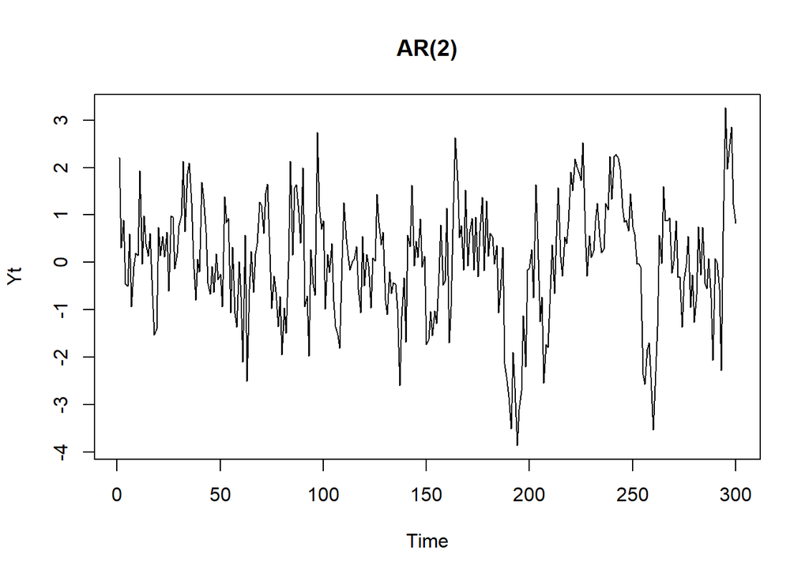

```r
plot.ts(Y_AR2_sim, main = "AR(2)", ylab = "Yt")
```

**Interpretasi:** deretnya berosilasi di sekitar rata-rata konstan tanpa tren, variansinya juga relatif stabil dari waktu ke waktu. Sesuai dugaan, karena parameter $\phi_1 = 0.5$ dan $\phi_2 = 0.2$ memang berada di kawasan yang membuat AR(2) ini stasioner.

## 4.3 Plot ACF, PACF, dan EACF

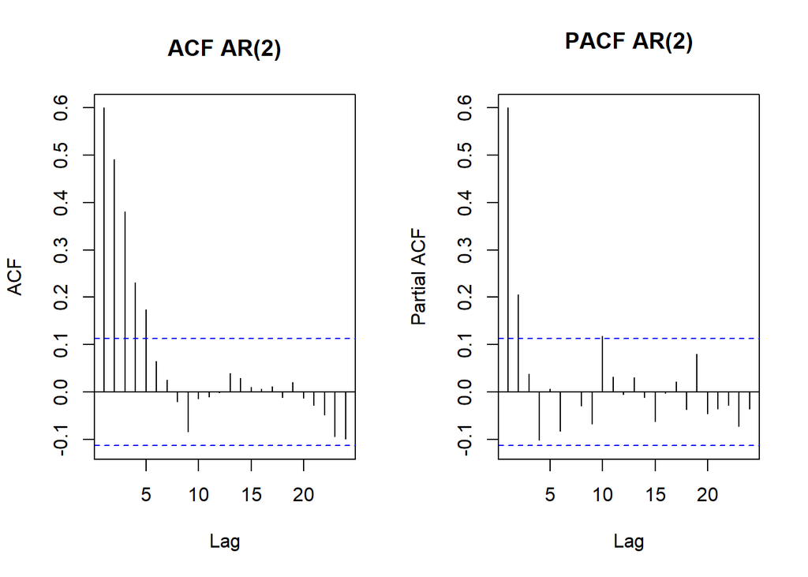

```r
par(mfrow = c(1, 2))
acf(Y_AR2_sim, main = "ACF AR(2)")
pacf(Y_AR2_sim, main = "PACF AR(2)")
```

```r
eacf(Y_AR2_sim)
```

```
## AR/MA
##   0 1 2 3 4 5 6 7 8 9 10 11 12 13
## 0 x x x x x o o o o o o  o  o  o
## 1 x o x o x o o o o o o  o  o  o
## 2 x o x o o o o o o o o  o  o  o
## 3 x x x o o o o o o o o  o  o  o
## 4 o x o o o o o o o o o  o  o  o
## 5 o x x o o o o o o o o  o  o  o
## 6 o x x o o o o o o o o  o  o  o
## 7 x o x o o x o o o o o  o  o  o
```

## 4.4 Scatterplot Antar-Lag

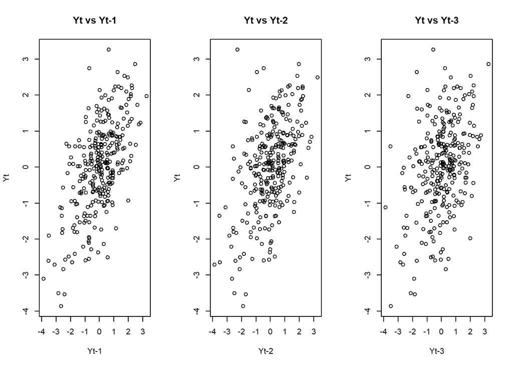

```r
par(mfrow = c(1, 3))
plot(Y_AR2_sim[-n], Y_AR2_sim[-1], xlab = "Yt-1", ylab = "Yt",
     main = "Yt vs Yt-1")
plot(Y_AR2_sim[1:(n-2)], Y_AR2_sim[3:n], xlab = "Yt-2", ylab = "Yt",
     main = "Yt vs Yt-2")
plot(Y_AR2_sim[1:(n-3)], Y_AR2_sim[4:n], xlab = "Yt-3", ylab = "Yt",
     main = "Yt vs Yt-3")
```

**Interpretasi:** berbeda dengan MA(2), pola linear pada scatterplot AR(2) masih terlihat — meski semakin melemah — hingga lag 3. Hal ini mencerminkan sifat “memori panjang” proses AR, di mana pengaruh nilai masa lalu tidak langsung hilang, melainkan meluruh secara bertahap seiring bertambahnya lag.

## 4.5 Autokorelasi: Empiris vs Teoritis

```r
acf_empiris_AR2 <- acf(Y_AR2_sim, plot = FALSE)$acf[2:4]

# Rumus teoritis ACF AR(2) via persamaan Yule-Walker
rho1_AR2 <- phi1 / (1 - phi2)
rho2_AR2 <- phi1 * rho1_AR2 + phi2 * 1
rho3_AR2 <- phi1 * rho2_AR2 + phi2 * rho1_AR2
acf_teoritis_AR2 <- c(rho1_AR2, rho2_AR2, rho3_AR2)

data.frame(Lag = 1:3, Empiris = acf_empiris_AR2, Teoritis = acf_teoritis_AR2)
```

[output not shown]

# 5 Proses ARMA(2,2)

Model yang disimulasikan: $Y_t = \phi_1 Y_{t-1} + \phi_2 Y_{t-2} + e_t + \theta_1 e_{t-1} + \theta_2 e_{t-2}$, dengan $\phi_1 = 0.5$, $\phi_2 = 0.2$, $\theta_1 = 0.4$, dan $\theta_2 = 0.6$. Proses ini menggabungkan komponen AR dan MA; kestasioneran ditentukan oleh komponen AR-nya saja (syarat sama seperti AR(2) di atas), sedangkan komponen MA hanya memengaruhi bentuk pola ACF pada lag-lag awal.

## 5.1 Membangkitkan Data

```r
# Cara 1: manual, gabungan rekursif AR dan MA, dengan burn-in
e3 <- rnorm(n + 100, mean = 0, sd = 1)
Y_ARMA22_manual <- numeric(n + 100)
Y_ARMA22_manual[1] <- e3[1]
Y_ARMA22_manual[2] <- e3[2]
for (t in 3:(n + 100)) {
  Y_ARMA22_manual[t] <- phi1 * Y_ARMA22_manual[t - 1] + phi2 * Y_ARMA22_manual[t - 2] +
                         e3[t] + theta1 * e3[t - 1] + theta2 * e3[t - 2]
}
Y_ARMA22_manual <- ts(Y_ARMA22_manual[101:(n + 100)])

# Cara 2: menggunakan fungsi bawaan arima.sim
Y_ARMA22_sim <- arima.sim(model = list(ar = c(phi1, phi2), ma = c(theta1, theta2)), n = n)
```

**Catatan:** ARMA(2,2) ini gabungan dua sifat sekaligus — bagian AR-nya bikin proses harus dihitung lewat loop berurutan (karena butuh $Y_{t-1}$, $Y_{t-2}$) dan tetap perlu *burn-in*, sementara bagian MA-nya menambah ketergantungan ke dua error sebelumnya ($e_{t-1}$, $e_{t-2}$) di iterasi yang sama. Jadi meskipun ada unsur “rumus langsung” dari sisi error, proses ini tetap harus dianggap rekursif secara keseluruhan karena komponen AR-nya.

## 5.2 Plot Time Series

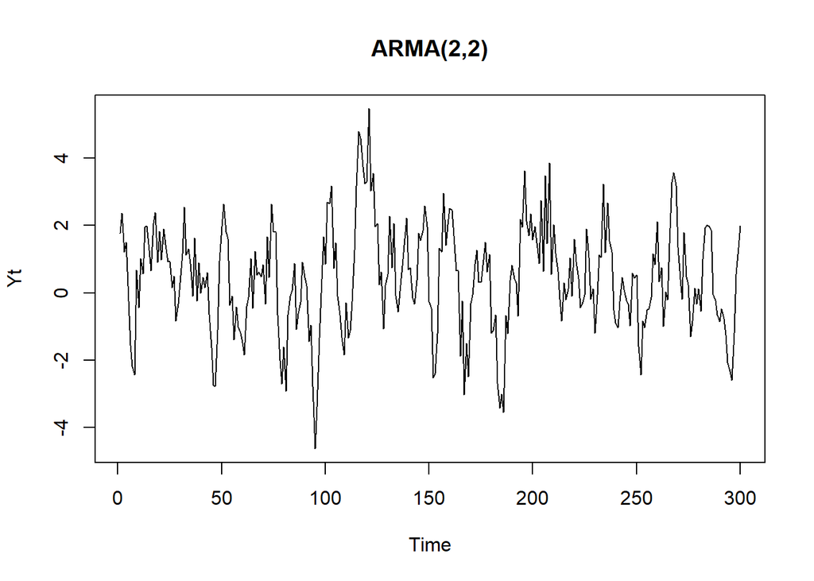

```r
plot.ts(Y_ARMA22_sim, main = "ARMA(2,2)", ylab = "Yt")
```

*(Plot ACF, PACF, EACF, dan scatterplot di bawah ini juga pakai data `arima.sim` yang sama, tidak dua-duanya seperti bagian pembangkitan data di atas.)*

**Interpretasi:** polanya mirip AR(2) — berosilasi stabil di sekitar rata-rata konstan, variansi juga tidak berubah banyak sepanjang waktu. Wajar, karena kestasioneran ARMA ditentukan komponen AR-nya, dan parameter $\phi_1$, $\phi_2$ yang dipakai sama persis dengan kasus AR(2) di atas.

## 5.3 Plot ACF, PACF, dan EACF

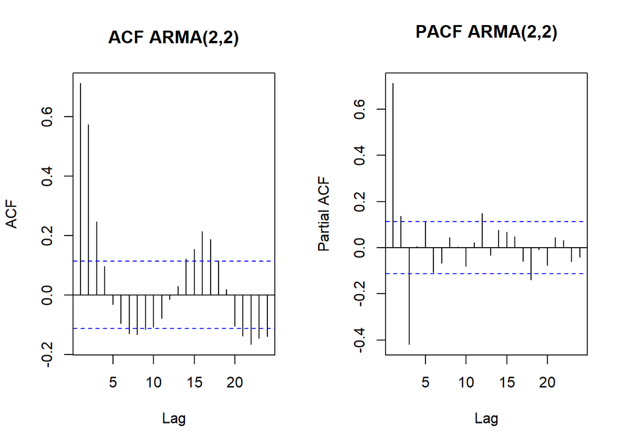

```r
par(mfrow = c(1, 2))
acf(Y_ARMA22_sim, main = "ACF ARMA(2,2)")
pacf(Y_ARMA22_sim, main = "PACF ARMA(2,2)")
```

```r
eacf(Y_ARMA22_sim)
```

```
## AR/MA
##   0 1 2 3 4 5 6 7 8 9 10 11 12 13
## 0 x x x o o o x x o o o  o  o  x
## 1 x x o o o o o o o o o  o  o  o
## 2 x x o x o o o o o o o  o  o  o
## 3 o x x o o o o o o o o  o  o  o
## 4 o x x o o o o o o o o  o  o  o
## 5 x x x o o o o o o o o  o  o  o
## 6 x x x o x o o o o o o  o  o  o
## 7 x x x x o o o o o o o  o  o  o
```

## 5.4 Scatterplot Antar-Lag

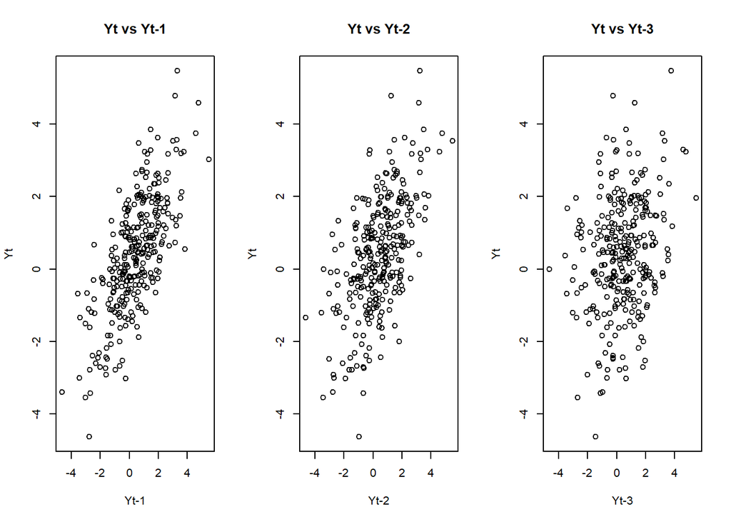

```r
par(mfrow = c(1, 3))
plot(Y_ARMA22_sim[-n], Y_ARMA22_sim[-1], xlab = "Yt-1", ylab = "Yt",
     main = "Yt vs Yt-1")
plot(Y_ARMA22_sim[1:(n-2)], Y_ARMA22_sim[3:n], xlab = "Yt-2", ylab = "Yt",
     main = "Yt vs Yt-2")
plot(Y_ARMA22_sim[1:(n-3)], Y_ARMA22_sim[4:n], xlab = "Yt-3", ylab = "Yt",
     main = "Yt vs Yt-3")
```

**Interpretasi:** pola korelasi antar-lag mencerminkan gabungan efek AR (meluruh perlahan) dan MA (menguat pada dua lag pertama). Secara umum pola linear masih tampak jelas pada lag 1 dan 2, dan masih menyisakan sedikit pola pada lag 3 — lebih kuat dibanding MA(2) murni — karena adanya kontribusi komponen AR yang meneruskan pengaruh nilai masa lalu.

## 5.5 Autokorelasi: Empiris vs Teoritis

```r
acf_empiris_ARMA22 <- acf(Y_ARMA22_sim, plot = FALSE)$acf[2:4]

# ACF teoritis ARMA campuran dihitung dengan fungsi bawaan R (ARMAacf),
# karena rumus tertutupnya melibatkan cross-covariance antara Y dan e
acf_teoritis_ARMA22 <- ARMAacf(ar = c(phi1, phi2), ma = c(theta1, theta2), lag.max = 3)[2:4]

data.frame(Lag = 1:3, Empiris = acf_empiris_ARMA22, Teoritis = acf_teoritis_ARMA22)
```

[output not shown]

# 6 Kesimpulan